# Construcción de Modelos - Chapter 24

```r
library(tidyverse)
library(modelr)
library(lubridate)
library(datos)
options(na.action = na.warn)
```

## ¿Por qué los diamantes de baja calidad son más caros?

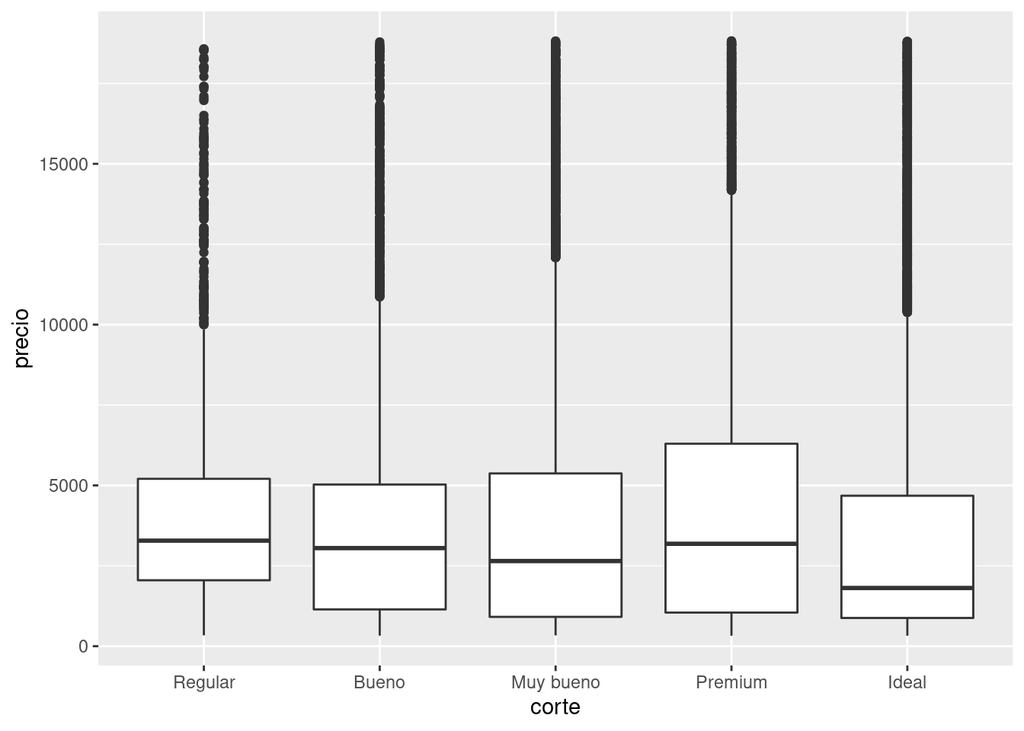

```r
ggplot(diamantes, aes(corte, precio)) + geom_boxplot()
```

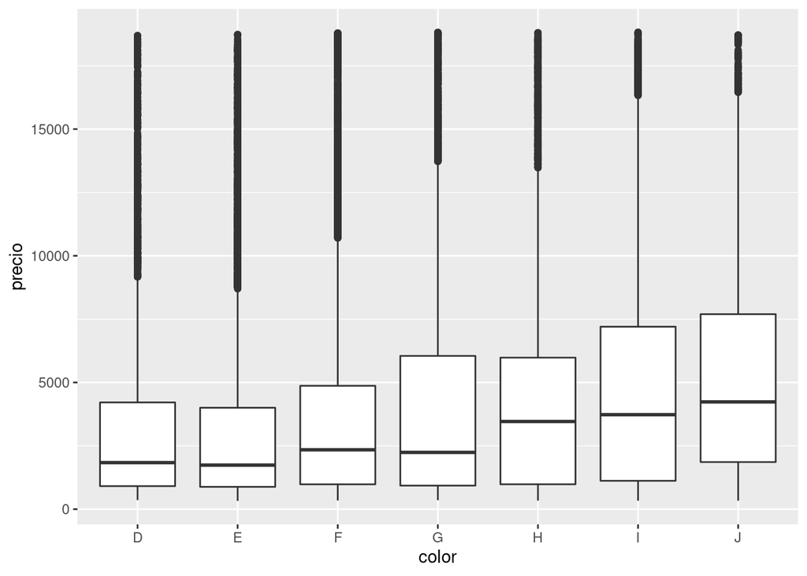

```r
ggplot(diamantes, aes(color, precio)) + geom_boxplot()
```

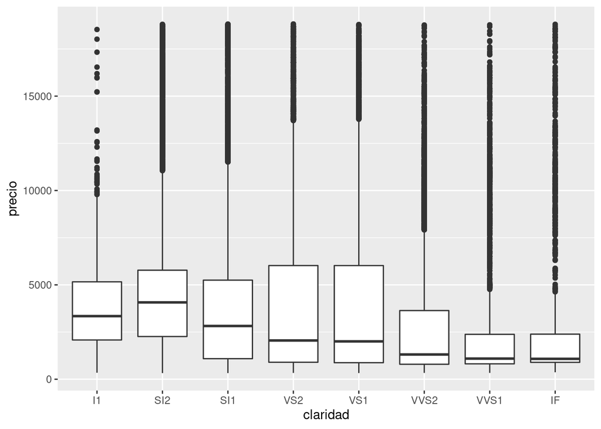

```r
ggplot(diamantes, aes(claridad, precio)) + geom_boxplot()
```

## Precio y quilates

Pareciera que los diamantes de menor calidad tiene precios más altos porque hay una importante variable de confusión: el peso (carat) del diamante. El peso del diamante es el factor individual más importante para determinar el precio del diamante, y los diamantes de menor calidad tienden a ser más grandes.

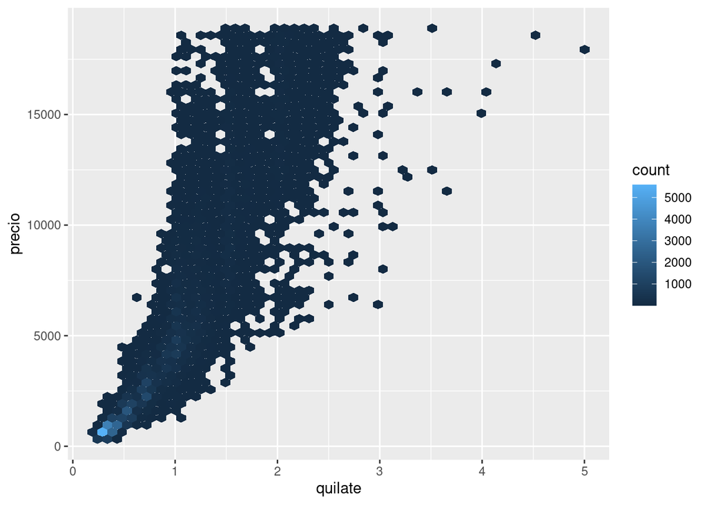

```r
ggplot(diamantes, aes(quilate, precio)) +
  geom_hex(bins = 50)
```

Hagamos **algunos ajustes** al conjunto de datos de diamantes para que sea más fácil trabajar con ellos:

1. Foco en los diamantes más pequeños que 2.5 quilates (99.7% de los datos).
2. Haz una transformación logarítmica de las variables quilates y precio

```r
diamantes2 <- diamantes %>%
  filter(quilate <= 2.5) %>%
  mutate(log_precio = log2(precio), log_quilates = log2(quilate))
```

Juntos, esos cambios hacen más fácil ver la relación entre quilates y precio:

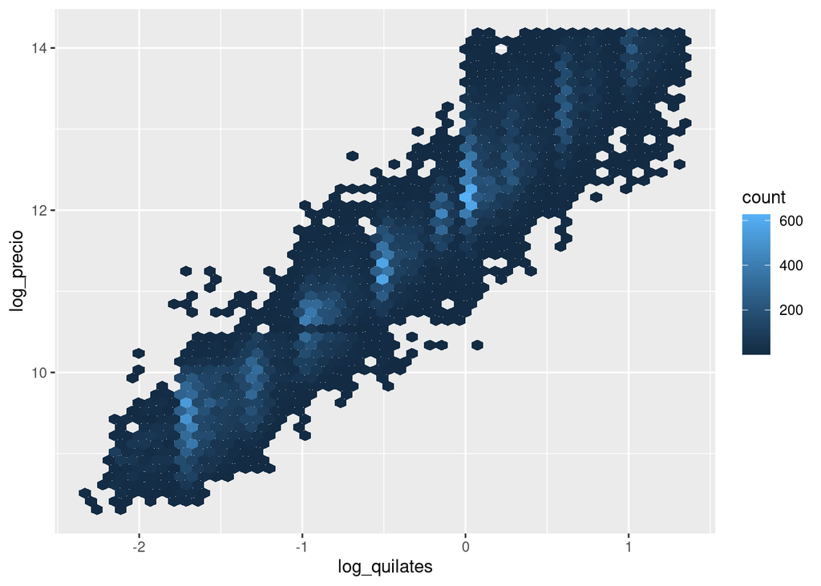

```r
ggplot(diamantes2, aes(log_quilates, log_precio)) +
  geom_hex(bins = 50)
```

La transformación logarítmica es particularmente util aquí porque hace que el patrón sea lineal, y patrones lineales son más fáciles de usar.

Tomemos el próximo paso y eliminemos ese patron lineal fuerte. Primero hacemos explícito el patrón ajustando el modelo:

```r
mod_diamantes <- lm(log_precio ~ log_quilates, data = diamantes2)
```

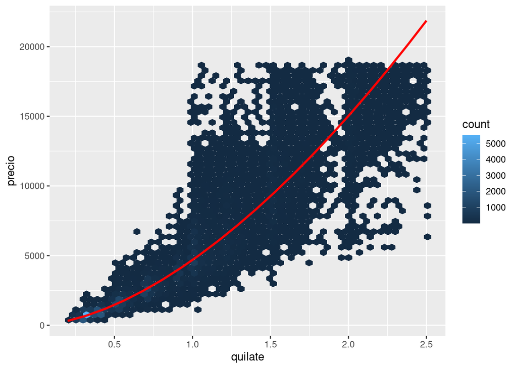

```r
cuadricula <- diamantes2 %>%
  data_grid(quilate = seq_range(quilate, 20)) %>%
  mutate(log_quilates = log2(quilate)) %>%
  add_predictions(mod_diamantes, "log_precio") %>%
  mutate(precio = 2 ^ log_precio)

ggplot(diamantes2, aes(quilate, precio)) +
  geom_hex(bins = 50) +
  geom_line(data = cuadricula, colour = "red", size = 1)
```

Si creemos en nuestro modelo, los diamantes grandes son mucho más baratos que lo esperado. Esto es posiblemente porque ninguno de los diamantes de estos datos cuesta más de US$19,000.

Ahora podemos ver los residuos, lo cual comprueba que hemos eliminado el patrón lineal fuerte:

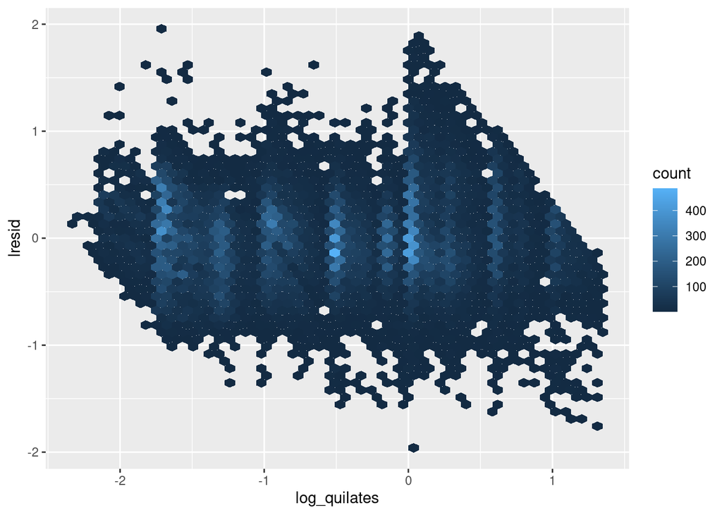

```r
diamantes2 <- diamantes2 %>%
  add_residuals(mod_diamantes, "lresid")

ggplot(diamantes2, aes(log_quilates, lresid)) +
  geom_hex(bins = 50)
```

Es importante destacar que ahora podemos volver a hacer nuestros gráficos motivadores utilizando esos residuos en lugar de precio.

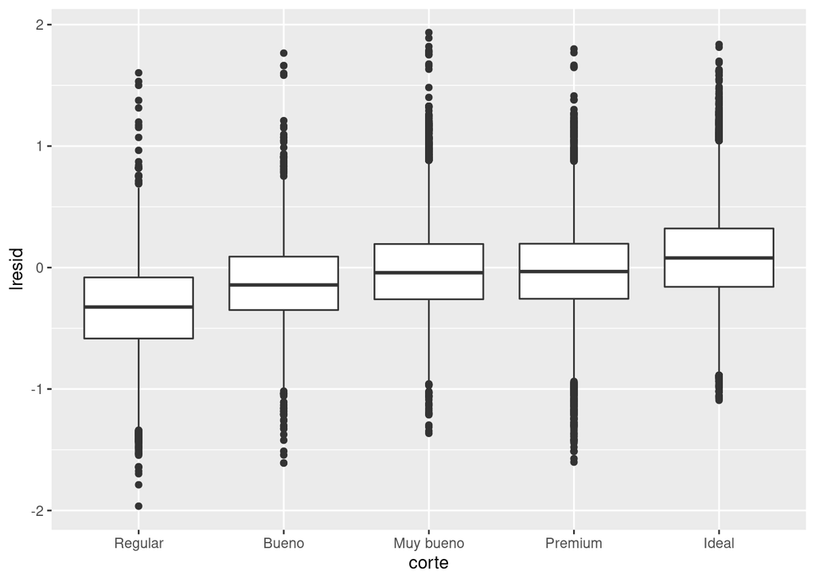

```r
ggplot(diamantes2, aes(corte, lresid)) + geom_boxplot()
```

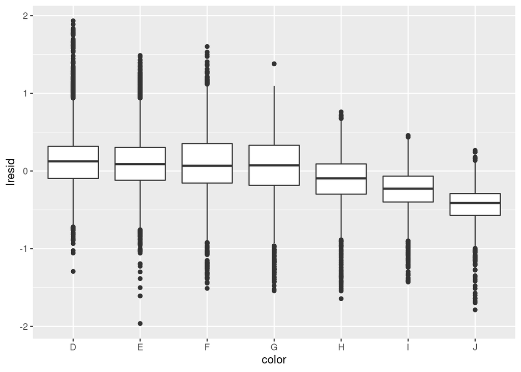

```r
ggplot(diamantes2, aes(color, lresid)) + geom_boxplot()
```

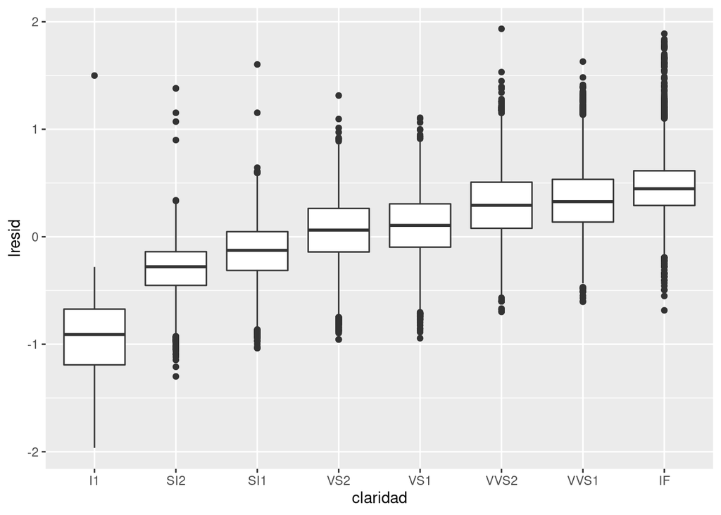

```r
ggplot(diamantes2, aes(claridad, lresid)) + geom_boxplot()
```

Ahora vemos la relación que esperábamos: a medida que aumenta la calidad del diamante, también lo hace su precio relativo. Para interpretar el eje y, necesitamos pensar que nos dicen los residuos, y en que escala están. Un residuo de -1 indica que log_precio era 1 unidad más baja que la predicción basada únicamente en su peso. 2−1 es 1/2, los puntos con un valor de -1 son la mitad del precio esperado, y los residuos con el valor 1 son el doble del precio predicho

## Un modelo más complicado

Si quisiéramos, podríamos continuar construyendo nuestro modelo, traspasando los resultados que hemos observado en el modelo para hacerlos explícitos. Por ejemplo, **podríamos incluir color, corte, y claridad en el modelo para que también hagamos explícito el efecto de esas tres variables categóricas:**

```r
mod_diamantes2 <- lm(log_precio ~ log_quilates + color + corte + claridad, data = diamantes2)
```

Este modelo ahora incluye cuatro predictores, por lo que es más difícil de visualizar. Afortunadamente, todos ellos son actualmente independientes lo que significa que podemos graficarlos individualmente en cuatro gráficos. Para hacer el proceso más fácil, vamos a usar el argumento .model en data_grid:

```r
cuadricula <- diamantes2 %>%
  data_grid(corte, .model = mod_diamantes2) %>%
  add_predictions(mod_diamantes2)
cuadricula
```

```
## # A tibble: 5 x 5
##   corte     log_quilates color claridad  pred
##   <ord>            <dbl> <chr> <chr>    <dbl>
## 1 Regular         -0.515 G     VS2       11.2
## 2 Bueno           -0.515 G     VS2       11.3
## 3 Muy bueno       -0.515 G     VS2       11.4
## 4 Premium         -0.515 G     VS2       11.4
## 5 Ideal           -0.515 G     VS2       11.4
```

[output not shown]

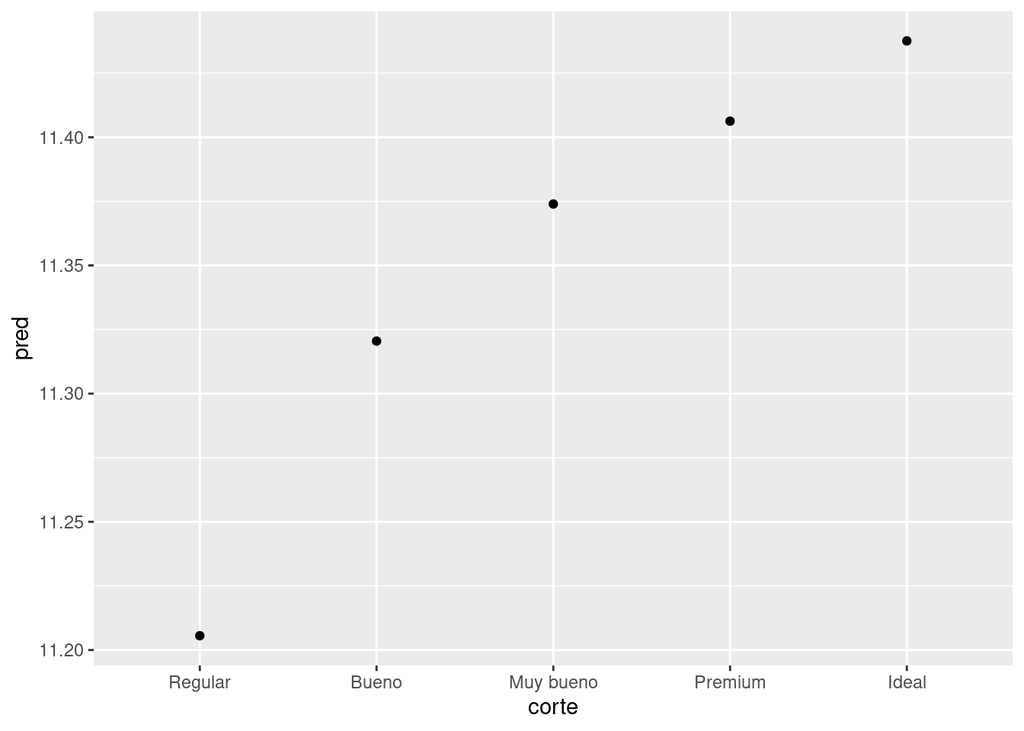

```r
ggplot(cuadricula, aes(corte, pred)) +
  geom_point()
```

Si el modelo necesita variables que no has suministrado, data_grid() automáticamente los rellenará con el valor “typical”. Para variables continuas, se usa la mediana, y para variables categóricas se usa el valor más frecuente (o valores, si hay un empate).

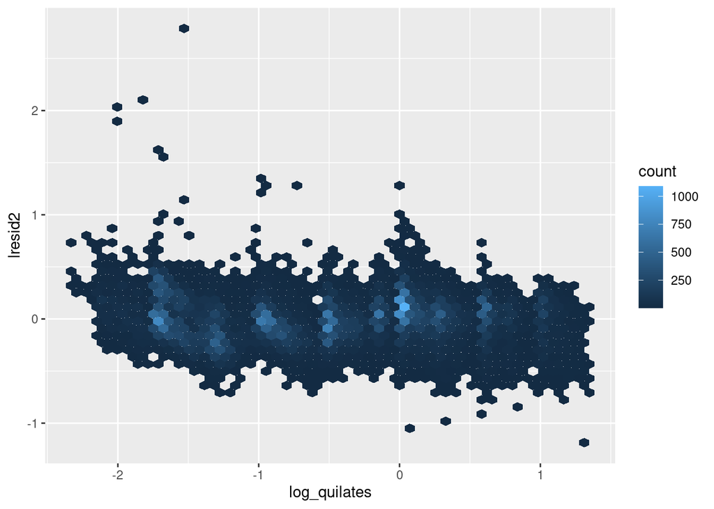

```r
diamantes2 <- diamantes2 %>%
  add_residuals(mod_diamantes2, "lresid2")

ggplot(diamantes2, aes(log_quilates, lresid2)) +
  geom_hex(bins = 50)
```

Este gráfico indica que hay algunos diamantes con residuos bastante grandes - recuerda que un residuo de 2 indica que el diamante es 4x el precio que esperábamos. A menudo es útil mirar los valores inusuales individualmente:

```r
diamantes2 %>%
  filter(abs(lresid2) > 1) %>%
  add_predictions(mod_diamantes2) %>%
  mutate(pred = round(2 ^ pred)) %>%
  select(precio, pred, quilate:tabla, x:z) %>%
  arrange(precio)
```

```
## # A tibble: 16 x 11
##    precio  pred quilate corte color claridad profundidad tabla     x     y     z
##     <int> <dbl>   <dbl> <ord> <ord> <ord>          <dbl> <dbl> <dbl> <dbl> <dbl>
##  1   1013   264   0.25  Regu… F     SI2             54.4    64  4.3   4.23  2.32
##  2   1186   284   0.25  Prem… G     SI2             59      60  5.33  5.28  3.12
##  3   1186   284   0.25  Prem… G     SI2             58.8    60  5.33  5.28  3.12
##  4   1262  2644   1.03  Regu… E     I1              78.2    54  5.72  5.59  4.42
##  5   1415   639   0.35  Regu… G     VS2             65.9    54  5.57  5.53  3.66
##  6   1415   639   0.35  Regu… G     VS2             65.9    54  5.57  5.53  3.66
##  7   1715   576   0.32  Regu… F     VS2             59.6    60  4.42  4.34  2.61
##  8   1776   412   0.290 Regu… F     SI1             55.8    60  4.48  4.41  2.48
##  9   2160   314   0.34  Regu… F     I1              55.8    62  4.72  4.6   2.6
## 10   2366   774   0.3   Muy … D     VVS2            60.6    58  4.33  4.35  2.63
## 11   3360  1373   0.51  Prem… F     SI1             62.7    62  5.09  4.96  3.15
## 12   3807  1540   0.61  Bueno F     SI2             62.5    65  5.36  5.29  3.33
## 13   3920  1705   0.51  Regu… F     VVS2            65.4    60  4.98  4.9   3.23
## 14   4368  1705   0.51  Regu… F     VVS2            60.7    66  5.21  5.11  3.13
## 15  10011  4048   1.01  Regu… D     SI2             64.6    58  6.25  6.2   4.02
## 16  10470 23622   2.46  Prem… E     SI2             59.7    59  8.82  8.76  5.25
```

Hasta aquí nada realmente interesante, pero probablemente valga la pena pasar tiempo considerando si esto significa un problema con nuestro modelo, o si hay errores en los datos. Si hay errores en los datos, esta podría ser una oportunidad para comprar diamantes que fueron incorrectamente tasados con valor bajo.

## ¿Qué afecta el número de vuelos diarios?

Trabajaremos a través de un proceso similar para un conjunto de datos que parece aún más simple a primera vista: el número de vuelos que salen de NYC por día. Este es un conjunto realmente pequeño de datos — solo 365 filas y 2 columnas — y no vamos a terminar con un modelo completamente realizado, pero como veras, los pasos en el camino nos ayudarán a entender mejor los datos. Comenzaremos contando el número de vuelos por día y visualizándolos con ggplot2.

```r
vuelos_por_dia <- vuelos %>%
  mutate(fecha = make_date(anio, mes, dia)) %>%
  group_by(fecha) %>%
  summarise(n = n())
vuelos_por_dia
```

```
## # A tibble: 365 x 2
##    fecha          n
##    <date>     <int>
##  1 2013-01-01   842
##  2 2013-01-02   943
##  3 2013-01-03   914
##  4 2013-01-04   915
##  5 2013-01-05   720
##  6 2013-01-06   832
##  7 2013-01-07   933
##  8 2013-01-08   899
##  9 2013-01-09   902
## 10 2013-01-10   932
## # … with 355 more rows
```

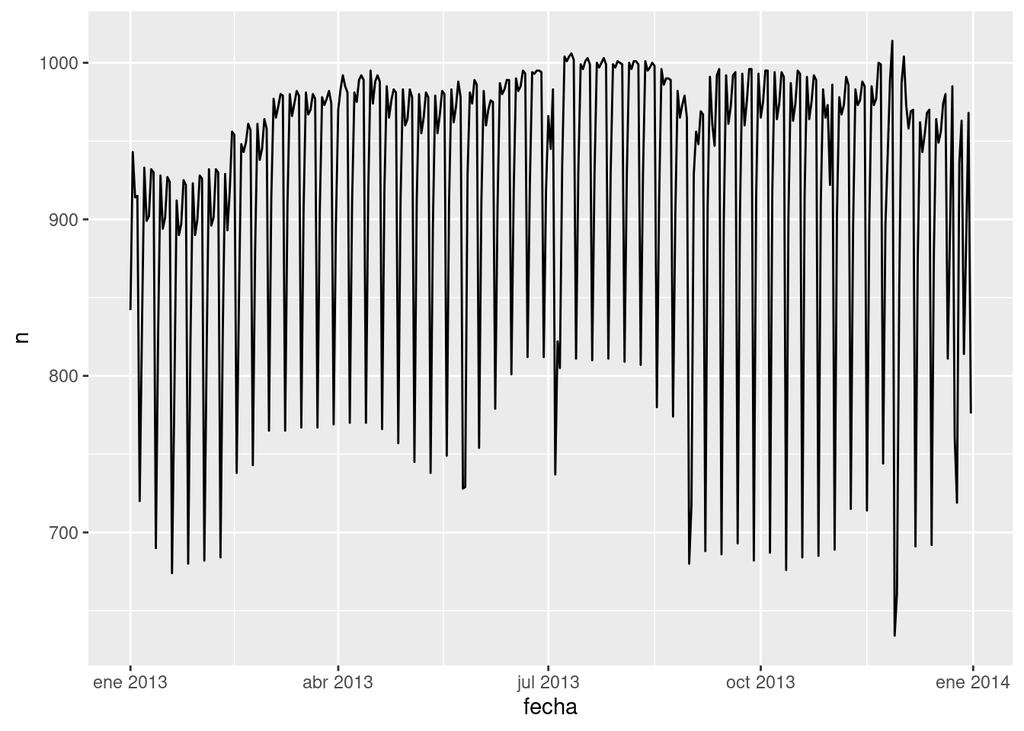

```r
ggplot(vuelos_por_dia, aes(fecha, n)) +
  geom_line()
```

## Día de la semana

Comprender la tendencia a largo plazo es un desafío porque hay un fuerte efecto de día de la semana que domina a los patrones más sutiles. Comenzaremos mirando la distribución de número de vuelos por día de la semana:

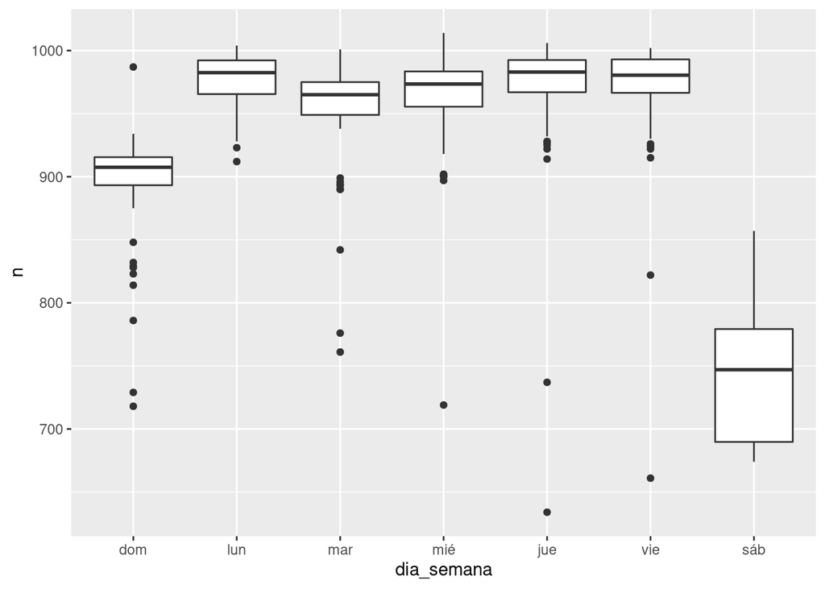

```r
vuelos_por_dia <- vuelos_por_dia %>%
  mutate(dia_semana = wday(fecha, label = TRUE))
ggplot(vuelos_por_dia, aes(dia_semana, n)) +
  geom_boxplot()
```

Hay pocos vuelos los fines de semana porque la mayoría de los viajes son por negocios. El efecto es particularmente pronunciado el sábado: alguna vez podrías salir un domingo para ir a una reunión un lunes por la mañana, pero es menos común que salgas un sábado ya que preferirías estar en casa con tu familia.

Una forma de eliminar este fuerte patrón es usar un modelo. Primero, ajustamos el modelo, y mostraremos sus predicciones superpuestas sobre los datos originales:

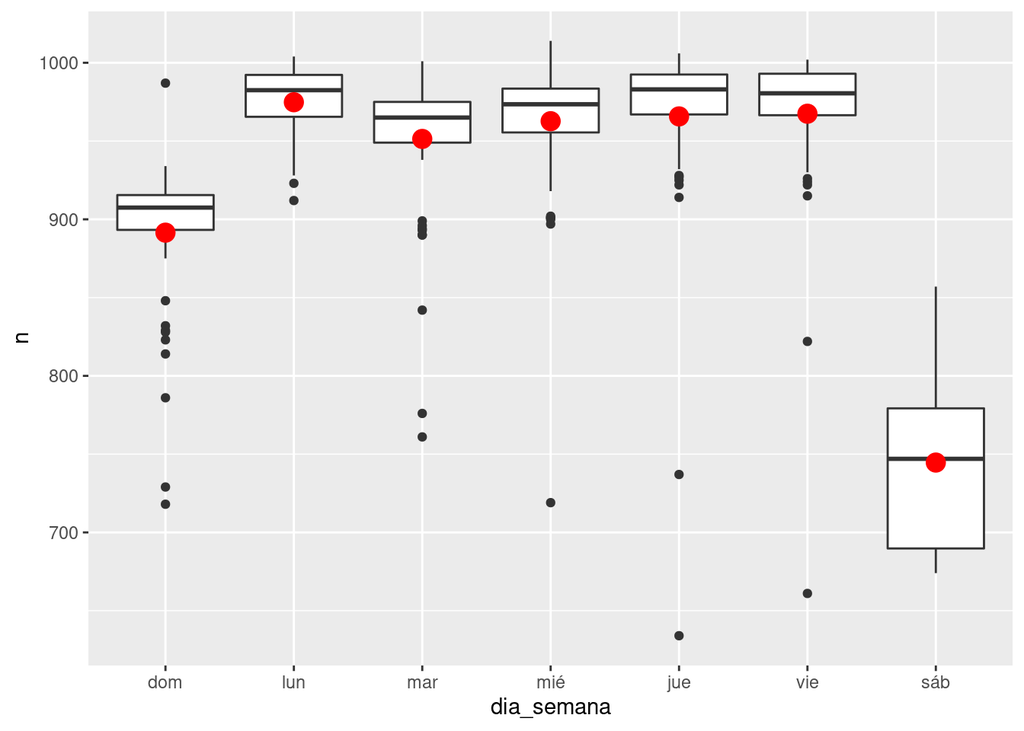

```r
mod <- lm(n ~ dia_semana, data = vuelos_por_dia)

cuadricula <- vuelos_por_dia %>%
  data_grid(dia_semana) %>%
  add_predictions(mod, "n")

ggplot(vuelos_por_dia, aes(dia_semana, n)) +
  geom_boxplot() +
  geom_point(data = cuadricula, colour = "red", size = 4)
```

**A continuación calculamos y visualizamos los residuos:**

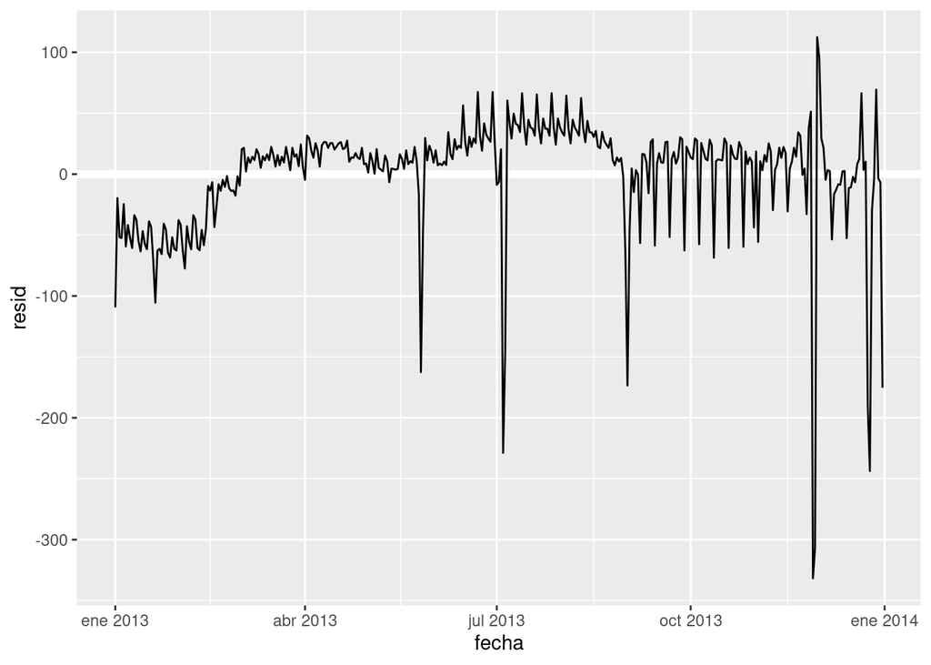

```r
vuelos_por_dia <- vuelos_por_dia %>%
  add_residuals(mod)
vuelos_por_dia %>%
  ggplot(aes(fecha, resid)) +
  geom_ref_line(h = 0) +
  geom_line()
```

Notar el cambio en el eje Y: ahora estamos viendo el desvío desde el número de vuelos esperados, dado el día de la semana. Este gráfico es útil porque ahora que removimos la mayor parte del efecto día de la semana, podemos ver algo de los patrones más sutiles que quedan:

Nuestro modelo parece fallar a partir de junio: todavía se puede ver un patrón regular fuerte que nuestro modelo no ha capturado. Dibujando un diagrama con una línea para cada día de la semana se hace más facil de ver la causa:

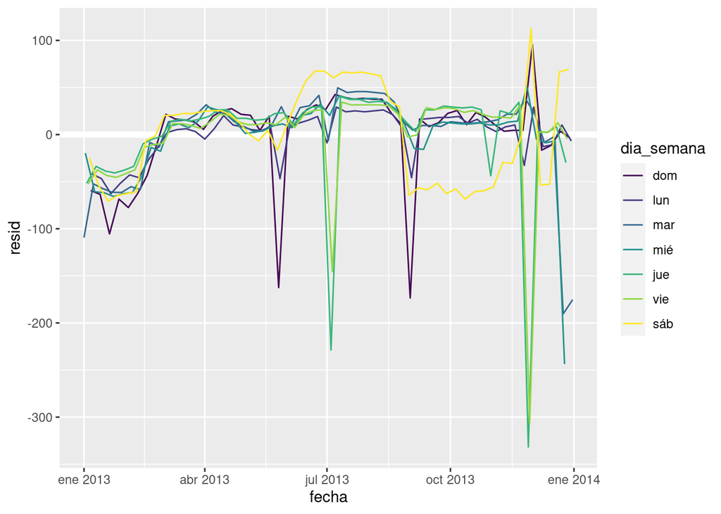

```r
ggplot(vuelos_por_dia, aes(fecha, resid, colour = dia_semana)) +
  geom_ref_line(h = 0) +
  geom_line()
```

Nuestro modelo falla en predecir con precisión el número de vuelos los sábados: durante el verano hay más vuelos de los que esperamos, y durante el otoño hay menos. Veremos como podemos capturar mejor este patrón en la siguiente sección.

Hay algunos días con mucho menos vuelos que los esperados:

```r
vuelos_por_dia %>%
  filter(resid < -100)
```

```
## # A tibble: 11 x 4
##    fecha          n dia_semana resid
##    <date>     <int> <ord>      <dbl>
##  1 2013-01-01   842 mar        -109.
##  2 2013-01-20   786 dom        -105.
##  3 2013-05-26   729 dom        -162.
##  4 2013-07-04   737 jue        -229.
##  5 2013-07-05   822 vie        -145.
##  6 2013-09-01   718 dom        -173.
##  7 2013-11-28   634 jue        -332.
##  8 2013-11-29   661 vie        -306.
##  9 2013-12-24   761 mar        -190.
## 10 2013-12-25   719 mié        -244.
## 11 2013-12-31   776 mar        -175.
```

Si estás familiarizado con los feriados públicos de Estados Unidos, podrías reconocer los días de Año Nuevo, el 4 de julio, el día de Acción de Gracias y Navidad. Hay algunos otros que parecen no corresponder a feriados públicos. Trabajarás sobre esos días en uno de los ejercicios.

Parece que hay una tendencia más suave a largo plazo en el transcurso del año. Podemos destacar esa tendencia con geom_smooth():

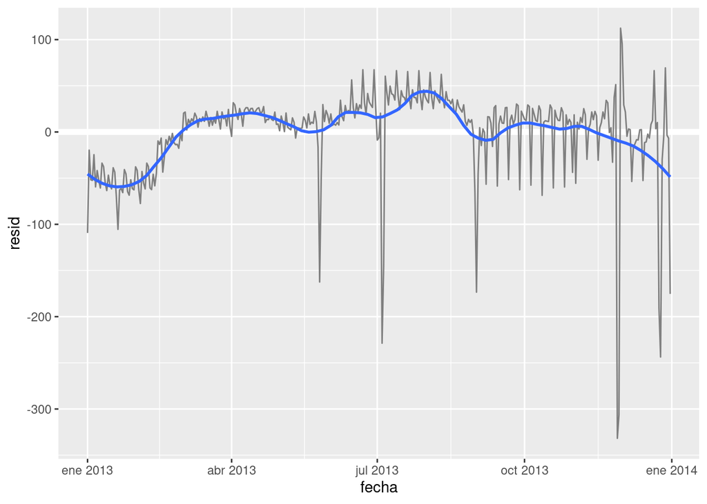

```r
vuelos_por_dia %>%
  ggplot(aes(fecha, resid)) +
  geom_ref_line(h = 0) +
  geom_line(colour = "grey50") +
  geom_smooth(se = FALSE, span = 0.20)
```

Hay menos vuelos en enero (y diciembre), y más en verano (May-Sep). No podemos hacer mucho cuantitativamente con este patrón, porque sólo tenemos un año de datos. Pero podemos usar nuestro conocimiento para pensar en posibles explicaciones.